# Analyzing the impact of different video topics and different days of the week on how long people spend watching videos

## Do Food Videos Change Our Viewing Time?

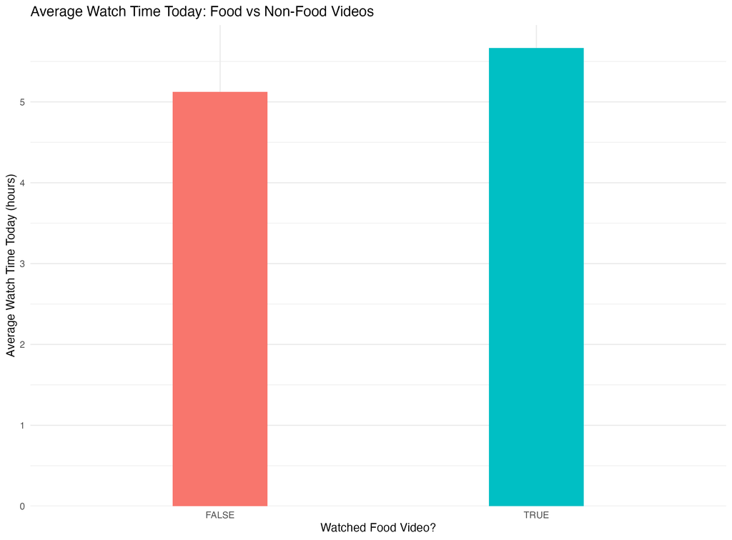

As shown, people who watched food videos tend to spend slightly more time watching overall, though the difference is modest.But it could show that *mukbang* slightly increases the length of time people watch videos.

## What Are the Most Engaging Topics?

We look at the most interesting video topics that students reported. This scatterplot shows how long people spent on different topics.

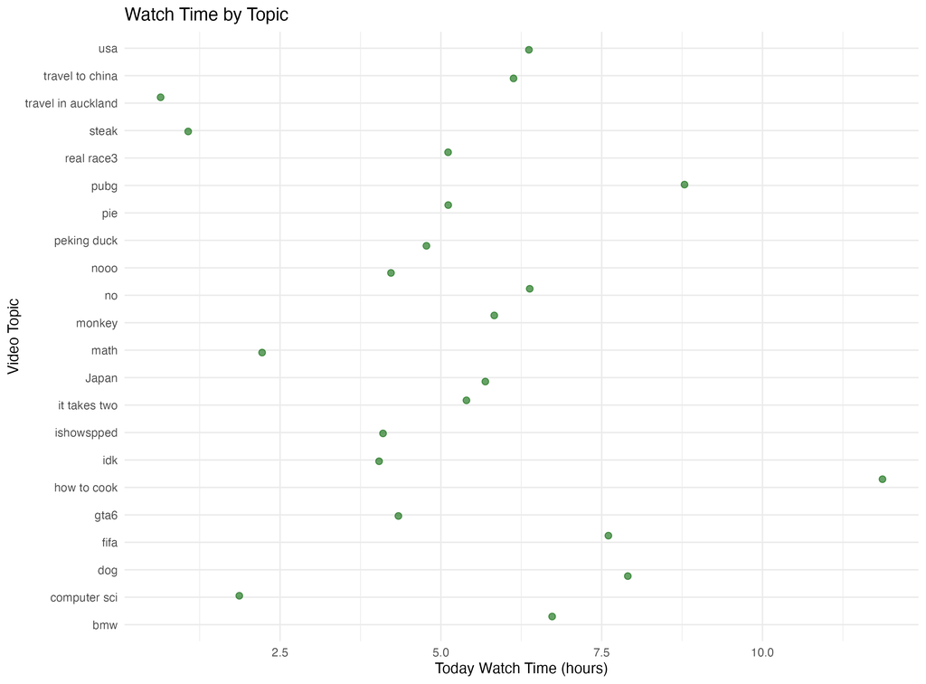

Some topics like **travel**, **games**, and **cooking** appear frequently. Even within the same genre, people’s engagement can vary widely.

## Is the length of time people watch videos affected by the day of the week?

This plot shows the **total amount of watch time** grouped by day of the week. It helps us understand if there is a pattern across the week.

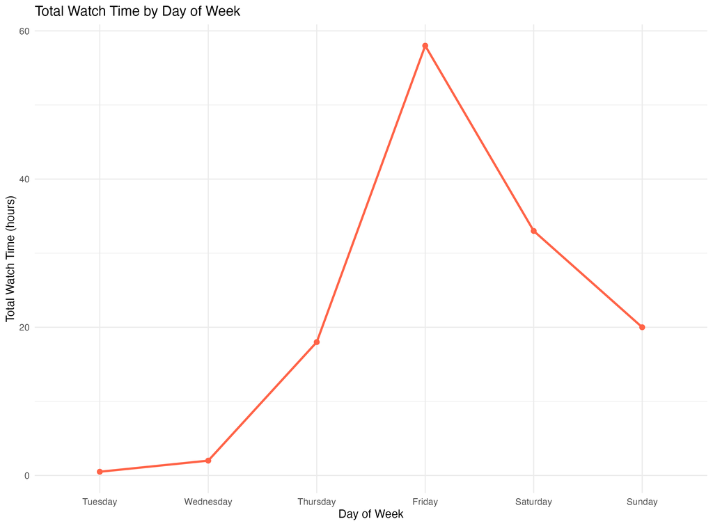